# Sparcc Simulation 3

Anonymous

08/27/2025

```r
rm(list = ls())
library(dplyr)
library(tidyverse)
library(ggplot2)
library(stringr)
library(ggh4x)
library(scales)
library(ggthemes)
library(kableExtra)
```

## Simulation Setup

The goal of this program is to evaluate the performance of the semiparametric efficient estimator $\widehat{\pmb{\beta}}_{sp}$ using simulations in the following setting:

- $Z \sim \textrm{Uniform}(0, \dots, p-1)$,
- $X|Z \sim \textrm{beta}(\pmb{\alpha}_1(Z))$,
- $C|Z \sim \textrm{beta}(\pmb{\alpha}_@(Z))$,
- $Y|X,Z \sim N(\beta_0 + \beta_1X + \beta_2Z, \sigma^2)$.

For each simulation, we generate a data set of size $n$ then compute the complete case estimator $\widehat{\pmb{\beta}}_{cc}$, the oracle estimator $\widehat{\pmb{\beta}}_{or}$, the parametric MLE $\widehat{\pmb{\beta}}_{ml}$, and the semiparametric efficient estimator $\widehat{\pmb{\beta}}_{sp}$ using either parametric or nonparametric nuisance distribution models.

```r
# true beta
B.true <- c(1, 10, 2, log(1))

# load simulation results from each of 10 clusters
sim.out.list <- lapply(
  X = 0:9,
  FUN = function(clust) {
    cbind(clust,
          read.csv(paste0(
            "sim3_data/sd",
            clust, ".csv")))
  })

# combine simulation results into 1 data frame
sim.out <- bind_rows(sim.out.list)

colnames(sim.out) <- gsub(".B", ".", colnames(sim.out))
colnames(sim.out) <- gsub("B2", "trueB2", colnames(sim.out))

# make long data frame
sim.out.long <- sim.out %>%
  pivot_longer(cols = starts_with(c("B", "V")),
               names_to = "method.param",
               values_to = "estimate") %>%
  mutate(name = factor(str_sub(method.param, 1, 1)),
         method = factor(str_sub(method.param, 3, 4),
                         levels = c("sp", "cc", "or"),
                         labels = c("Semipar", "CC", "Oracle")),
         nuis.x = factor(str_sub(str_sub(
           gsub("[.]", "", method.param), 4, -2), 1, 1),
           levels = c("", "1", "2"),
           labels = c("-", "Correct", "Nonpar")),
         nuis.c = factor(str_sub(str_sub(
           gsub("[.]", "", method.param), 4, -2), 2, 2),
           levels = c("", "1", "2"),
           labels = c("-", "Correct", "Nonpar")),
         param = factor(str_sub(method.param, -1, -1)),
         B.true = B.true[param]) %>%
  dplyr::select(-c(method.param)) %>%
  group_by(clust, n, q, ndistinct.Z, name, method, nuis.x, nuis.c, param) %>%
  mutate(id = row_number()) %>%
  pivot_wider(names_from = name,
              values_from = estimate,
              id_cols = c(clust, n, q, ndistinct.Z, method, nuis.x, nuis.c,
                          param, B.true, id)) %>%
  mutate(B = ifelse(abs(B - B.true) > 10, NA, B),
         ci.lower = B - qnorm(0.975) * V,
         ci.upper = B + qnorm(0.975) * V,
         ci.cov = B.true >= ci.lower & B.true <= ci.upper)
```

## Simulation Results

#### Errors in Simulations

We first look at which simulation settings lead to errors.

```r
# check for simulations with errors
sim.out.long %>%
  filter(param == 1) %>%
  group_by(q, n, ndistinct.Z, method, nuis.x, nuis.c) %>%
  summarize(n.error = sum(is.na(B)),
            prop.error = mean(is.na(B))) %>%
  filter(prop.error > 0) %>%
  kable(digits = 3) %>%
  kable_styling("striped")
```

q

n

ndistinct.Z

method

nuis.x

nuis.c

n.error

prop.error

0.8

8000

8

Semipar

Correct

Correct

1

0.001

0.8

8000

8

Semipar

Nonpar

Nonpar

1

0.001

0.8

8000

8

CC

1

0.001

0.8

8000

8

Oracle

1

0.001

#### Table of Results

```r
tbl1 <- sim.out.long %>%
  filter(param == 2) %>%
  mutate(dim.z = factor(log(as.numeric(ndistinct.Z), 2),
                        levels = 1:3,
                        labels = c("Univariate Z",
                                   "Bivariate Z",
                                   "Trivariate Z"))) %>%
  group_by(dim.z, method, nuis.x, nuis.c) %>%
  summarise(v1_Bias = 10*mean(B - B.true, na.rm = T),
            v2_ESE = 10*sd(B, na.rm = T),
            v3_ASE = 10*mean(V, na.rm = T),
            v4_Cov = 100*mean(ci.cov, na.rm = T))

kbl1 <- setNames(tbl1, c("Dimension of Z", "Method", "X|Z", "C|Z",
                 sub(".+_", "", tail(names(tbl1), -4)))) %>%
  kable(digits = c(0, 0, 0, 0,
                   2, 2, 2, 1),
        format = "latex",
        align = "ccccrrrr",
        booktabs = T) %>%
  kable_styling("striped") %>%
  row_spec(row = 0, bold = TRUE)
```

#### Plot of Results

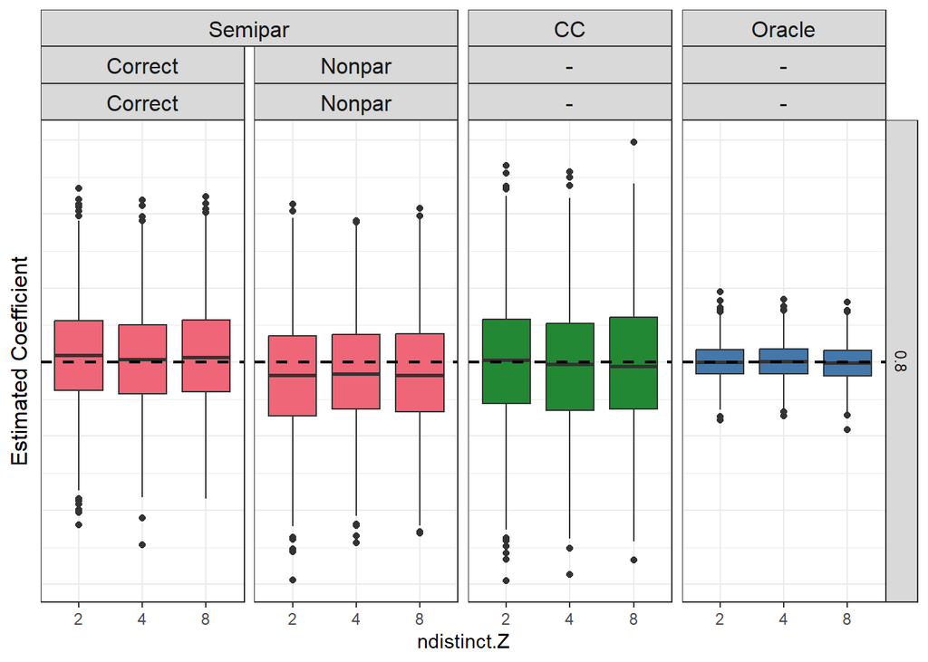

```r
pal_light <- c('#EE6677', '#228833', '#4477AA', '#CCBB44',
               '#66CCEE','#AA3377', '#BBBBBB')
font.size <- 12

sim.out.long %>%
  filter(param == 2) %>%
  mutate(ndistinct.Z = factor(ndistinct.Z)) %>%
  ggplot(aes(y = B,
             x = ndistinct.Z,
             fill = method)) +
  geom_boxplot() +
  geom_hline(aes(yintercept = B.true),
             linetype = "dashed",
             linewidth = 0.75) +
  facet_nested(q ~ method + nuis.x + nuis.c,
               scales = "free") +
  theme_bw() +
  theme(axis.ticks.y = element_blank(),
        axis.text.y = element_blank(),
        axis.title.y = element_text(size = font.size),
        strip.text.x = element_text(size = font.size)) +
  labs(y = "Estimated Coefficient") +
  guides(fill = "none", color = "none") +
  scale_fill_manual(values = pal_light[c(1, 2, 3, 5)])
```

#### Plot of Computation Times

```r
sim.out.time <- sim.out %>%
  select(ndistinct.Z, starts_with("time")) %>%
  pivot_longer(starts_with("time"),
               names_to = "proc",
               values_to = "time") %>%
  mutate(proc = gsub("time.", "", proc)) %>%
  separate(proc, into = c("proc1", "proc2"), sep = "[.]") %>%
  mutate(Proc1 = factor(proc1,
                        levels = c("xz", "cz", "est", "var"),
                        labels = c("X|Z Model", "C|Z Model",
                                   "Param. Est.",
                                   "Var. Est."),
                        ordered = T),
         Proc2 = factor(proc2,
                        levels = c("sp", "ml", "cc", "or",
                                   "param", "nonpar"),
                        labels = c("SPARCC", "MLE",
                                   "Complete Case", "Oracle",
                                   "Parametric", "Nonparametric"),
                        ordered = T))
```

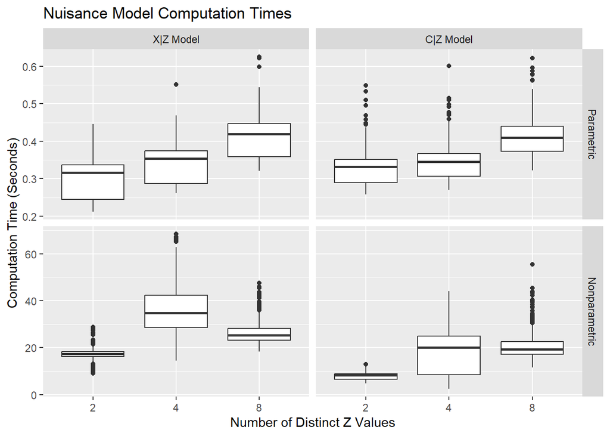

```r
# plot times for nuisance model fitting
sim.out.time %>%
  filter(proc1 %in% c("cz", "xz")) %>%
  mutate(ndistinct.Z = factor(ndistinct.Z)) %>%
  ggplot(aes(x = ndistinct.Z,
             y = time)) +
  geom_boxplot() +
  facet_grid(Proc2 ~ Proc1,
             scales = "free") +
  labs(x = "Number of Distinct Z Values",
       y = "Computation Time (Seconds)") +
  theme(legend.position = "bottom") +
  labs(title = "Nuisance Model Computation Times")
```

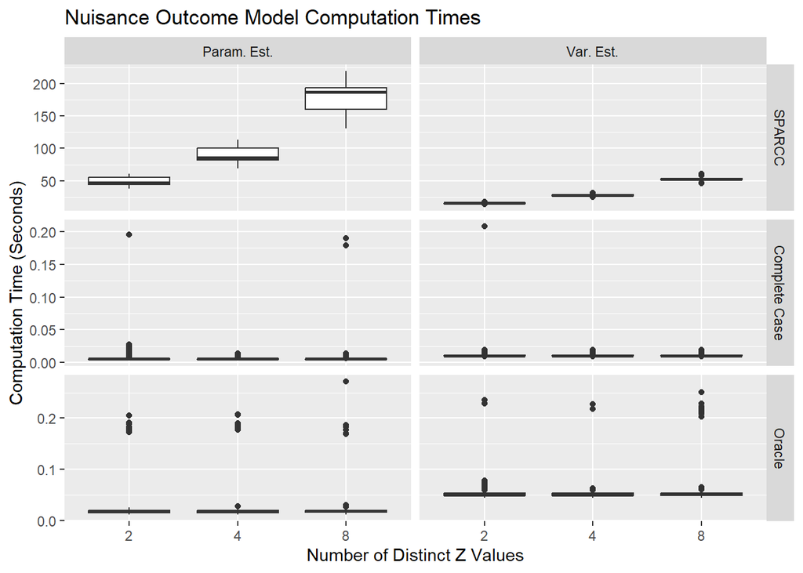

```r
# plot times for outcome model fitting
sim.out.time %>%
  filter(proc1 %in% c("est", "var")) %>%
  mutate(ndistinct.Z = factor(ndistinct.Z)) %>%
  ggplot(aes(x = ndistinct.Z,
             y = time)) +
  geom_boxplot() +
  facet_grid(Proc2 ~ Proc1,
             scales = "free") +
  labs(x = "Number of Distinct Z Values",
       y = "Computation Time (Seconds)") +
  theme(legend.position = "bottom") +
  labs(title = "Nuisance Outcome Model Computation Times")
```

#### Table of Computation Times

```r
tbl.time <- sim.out.time %>%
  filter(!is.na(time)) %>%
  group_by(ndistinct.Z, Proc1, Proc2) %>%
  summarise(mean = mean(time)) %>%
  select(ndistinct.Z, Proc1, Proc2, mean) %>%
  gather(key, value, mean) %>%
  unite(Group, ndistinct.Z, key) %>%
  spread(Group, value)

tbl.time
```

```
## # A tibble: 10 × 5
## # Groups:   Proc1 [4]
##    Proc1       Proc2         `2_mean` `4_mean`  `8_mean`
##    <ord>       <ord>            <dbl>    <dbl>     <dbl>
##  1 X|Z Model   Parametric     0.299    0.338     0.407
##  2 X|Z Model   Nonparametric 16.9     35.8      26.1
##  3 C|Z Model   Parametric     0.326    0.342     0.410
##  4 C|Z Model   Nonparametric  7.82    18.2      20.5
##  5 Param. Est. SPARCC        49.1     90.1     179.
##  6 Param. Est. Complete Case  0.00674  0.00627   0.00667
##  7 Param. Est. Oracle         0.0187   0.0186    0.0186
##  8 Var. Est.   SPARCC        15.3     27.6      52.2
##  9 Var. Est.   Complete Case  0.0111   0.0110    0.0108
## 10 Var. Est.   Oracle         0.0513   0.0512    0.0527
```

```r
kbl.time <- setNames(tbl.time, c("Task", "Method",
                                 "Univariate Z",
                                 "Bivariate Z",
                                 "Trivariate Z")) %>%
  kable(digits = c(0, 0,
                   rep(1, 6)),
        format = "latex",
        align = "ccrrrrrr",
        booktabs = T) %>%
  kable_styling("striped") %>%
  row_spec(row = 0, bold = TRUE)
```